# Research Notebook

# **Introduction/Abstract:**

The rapid advancements in AI technology has led to an increased adoption and integration of AI into various applications and systems. The introduction of natural language processing models like ChatGPT, has revolutionized the way individuals interact with technology. ChatGPT is a model developed by open AI which generates human-like text responses. The introduction of such models has had an impact on wide range of topics, such as job markets, education sector, accessibility and automation of tasks, business models, etc. The research notebook aims to study the perception and acceptance of individuals for AI models like chatGPT. We also try to understand the attitudes, beliefs, and concerns of the users regarding human-computer interactions by scraping tweets, reddit comments, and news articles related to chatGPT and analyzing it using various text mining methods.

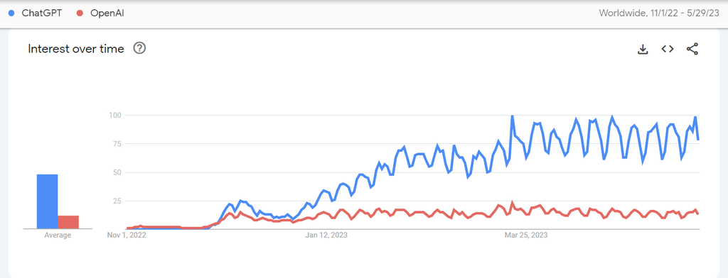

**Interest of ChatGPT reported by google trends**

# **Short problem statement & research question:**

What are the prevailing public sentiments, opinions, and concerns about the large language models like chatGPT expressed on social media platforms such as Twitter?

**Subquestions:**

- We know that the different social media platforms can contain a mix of personal opinions, and biases. What are the diverse opinions and concerns expressed on different social media platforms regarding ChatGPT and the increasing use of AI?
- Has the perception of people changed with the further advancement of chatGPT, are there changes in the sentiments or importance of topics?
- Are the viewpoints of public on twitter different for different sectors such as education and job market regarding chatgpt.

# **Methodological design**

The research design best-suited to answer our research questions concerns descriptive research, using Tweets, reddit comments, and news articles collected from various sources such as Kaggle, scraping webpages using their API. We divide our text mining process into different stages namely, collecting data, data cleaning, analysis and visualisation.

- We will perform sentiment analysis as it is the forefront of informing public interest and can be used as a monitoring tool for the evaluation of the impact of chatGPT.
- We will do topic modelling, using Latent Dirichlet Allocation which is an unsupervised classifcation algorithm, which discovers latent topics in a collection of text documents. We can gain insights into how ChatGPT has affected people and the nature of their discussions, by discovering emerging topics of tweets.
- We compare the sentiment, and main topics among various media sources such as Twitter, Reddit comments, News articles. By analyzing a variety of sources, we try to gain a more comprehensive understanding of the range of views on ChatGPT and thereby the increasing use of AI.
- We will also use LDA to reveal how the discussion topics related to ChatGPT have evolved over time. This will help track the changing perceptions, trends, or emerging issues as more people engage with ChatGPT. We will also see how the sentiment of people changed over time.
- Compare user segments: By segmenting the tweets based on keywords such as education, students, universities, we will compare the topics discussed by different user groups. This analysis will provide insights into how ChatGPT affects different segments of the population differently.

# **Description of data (collection)**

We used the following data sources for the collection of data for our analysis:

- Kaggle: We downloaded the following datasets:
  - ChatGPT 1000 Daily Tweets (recent tweets in April and May, 2023)
  - ChatGPT Tweets first month of launch (tweets in November and December, 2022)
  - ChatGPT-related Tweets Jan-Mar 2023
  - ChatGPT Reddit
- News API: We scraped recent 500 news articles sorted by popularity having the word ‘chatGPT’, and saved it as a csv file.

```r
baseurl<- str_c("https://newsapi.org/v2/everything?q=chatgpt&language=en&sortBy=popularity&apiKey=84d2c2cc0884484b8f4282a255b08d20&page=")
tenpages=glue("{baseurl}{1:5}")

i = 1
j = 1

alldata = list()
while (j<11) {
  r = GET(tenpages[j])
  r_text = content(r, "text")
  data_json = fromJSON(r_text, flatten=T)
  alldata[[i]] = as.data.frame(data_json)
  i = i + 1
  j = j + 1}
d = rbindlist(alldata, fill=TRUE)
write.csv(d, "news_articles.csv", row.names = FALSE)
```

# **Data cleaning/wrangling steps:**

We need the following packages, and libraries for the smooth execution of the notebook.

```r
#Packages needed to run this notebook
#Data collection
install.packages("tidyverse")
install.packages("httr")
install.packages("jsonlite")
install.packages("glue")
install.packages("data.table")

###Data wrangling
install.packages("psych")
install.packages("reshape2")
install.packages("dplyr")
install.packages("tm")

###Sentiment/text analysis/Natural language processing
install.packages("quanteda.textmodels")
install.packages("quanteda.textstats")
install.packages("quanteda.textplots")
install.packages("tm")
install.packages("SnowballC")
install.packages("syuzhet")
install.packages("igraph")
install.packages("spacyr")
install.packages("udpipe")
install.packages("lexicon")
install.packages("textstem")

#Latent Dirichlet allocation
install.packages("topicmodels")
install.packages("ldatuning")
install.packages("LDAvis")
install.packages("servr")

#Visualization
install.packages("kableExtra")

#Data wranging,descriptives, tables etc.
library(tidyverse)
library(dplyr)
library(psych)
library(tibble)
library(reshape2)
library(kableExtra)

#Text analysis, NLP, sentiment etc.
library(glue)
library(lexicon)
library(quanteda)
library(quanteda.textmodels)
library(quanteda.textstats)
library(quanteda.textplots)
library(spacyr)
library(udpipe)
library(igraph)
library(tm)
library(SnowballC)
library(RColorBrewer)
library(syuzhet)

#LDA
library(topicmodels)
library(LDAvis)
library(servr)
library(ldatuning)
```

We know that the data scraped from social media sources such as Twitter, Reddit, NewsAPI cannot be directly used for our analysis, as it might contain irrelevant or sensitive information, such as URLs, email addresses, or personal names, hash-tags, HTML tags, special characters, punctuation, or numbers, common words that do not carry much information, such as “the,” “is,” or “and”. Thus we create a function to clean the data, by removing uninformative data, normalizing, and tokenizing to reduce the dimensionality of the data, improve processing efficiency, and focus on the meaningful content.

```r
clean_text<- function(df) {
  # convert data into corpus
  text_corpus <- Corpus(VectorSource(df$content))
  # lowercase corpus
  text_corpus <- tm_map(text_corpus, tolower)
  # remove stopwords
  text_corpus <- tm_map(text_corpus, removeWords, stopwords("english"))
  # remove numbers
  text_corpus <- tm_map(text_corpus, removeNumbers)
  # remove usernames
  remove_users <- function(x) gsub("[@][a - zA - Z0 - 9_]{1,15}", " ", x)
  text_corpus<- tm_map(text_corpus, remove_users)
  # remove urls
  remove_urls <- function(x) gsub("(http|https)[^([:blank:]|\\|<|&|#\n\r)]+", " ", x)
  text_corpus<- tm_map(text_corpus, remove_urls)
  #handle spaces
  Space <- content_transformer(function (x , pattern ) gsub(pattern, " ", x))
  text_corpus <- tm_map(text_corpus, Space, "/")
  text_corpus <- tm_map(text_corpus, Space, "@")
  text_corpus <- tm_map(text_corpus, Space, "\\|")
  text_corpus <- tm_map(text_corpus, stripWhitespace)
  # remove hashtags
  remove_ht <- function(x) gsub("(^|\\s)#[a-zA-Z]+", " ", x)
  text_corpus<- tm_map(text_corpus, remove_ht)
  # remove punctuation
  remove_punct <- function(x) gsub("[[:punct:] ]+", " ", x)
  text_corpus<- tm_map(text_corpus, remove_punct)
  # lemmatization

  text_df <- data.frame(text_clean = get("content", text_corpus), stringsAsFactors = FALSE)
  corpusclean <- tm_map(text_corpus, stemDocument)

  return(corpusclean)
}
```

The function clean_text takes in an input dataframe, and performs the pre-processing of the column content, to return cleaned, structured, and prepared corpus that facilitates our future analysis.

We look at the tweets before and after applying above function:

```r
# Reading the data
url="C:\\Users\\hp\\Downloads\\archive (3)\\chatgpt_daily_tweets.csv"
tweets = read.csv(url)
tweets=tweets[tweets$lang =='en',]
tweets1 <- tweets %>% sample_n(10000)
tweets1 <- rename(tweets1, content = text)
corpus_clean_tweets<-clean_text(tweets1)
```

```r
head(tweets1$content)
```

```
[1] "Microsoft just gutted the entire team protecting us from the ethical dangers of ChatGPT.  Unless we take action now the next disinformation nightmare could be unleashed. https://t.co/4ysarLsomN"
[2] "@sharifshameem much of what makes reliable agents difficult is just compressing the DOM to fit the prompt context while retaining as much information as possible. GPT4’s vision model seems like it could allow much higher bandwidth there so schizo GPT agent traffic doesn’t seem too far off lol"
[3] "RT @ChrisStaud: 7 new mind-blowing AI tools you don't want to miss:\n\n1. https://t.co/ecVbnJzh1F - ChatGPT in your browser\n2. https://t.co/x…"
[4] "RT @TonyRomm: damn the debt ceiling broke chatgpt before it broke me, guess ai sucks now lol https://t.co/eDFAYeh0il"
[5] "RT @rowancheung: ChatGPT creates fake citations when you ask for them. \n\nWith this AI tool, you can ask anything and get summaries of the t…"
[6] "RT @AIValleyHQ: ChatGPT and Bing are phenomenal AI.\n\nBut don't skip these 13 new AI websites to finish hours of your work in minutes:"
```

```r
text_df <- data.frame(text_clean = get("content", corpus_clean_tweets), stringsAsFactors = FALSE)
head(text_df$text_clean)
```

```
[1] "microsoft just gut entir team protect us ethic danger chatgpt unless take action now next disinform nightmar unleash"
[2] "sharifshameem much make reliabl agent difficult just compress dom fit prompt context retain much inform possibl gpt s vision model seem like allow much higher bandwidth schizo gpt agent traffic doesn t seem far lol"
[3] "rt chrisstaud new mind blow ai tool want miss chatgpt browser"
[4] "rt tonyromm damn debt ceil broke chatgpt broke guess ai suck now lol"
[5] "rt rowancheung chatgpt creat fake citat ask ai tool can ask anyth get summari t"
[6] "rt ivalleyhq chatgpt bing phenomen ai skip new ai websit finish hour work minut"
```

We can clearly see that there is a difference between the tweets, the pre-processed tweets are much clean, and have successfully remove most of the noise. Since we have different datasets for different parts of analysis, we will apply the function to all the texts and obtain clean data:

```r
url="C:\\Users\\hp\\Downloads\\archive (2)\\chatgpt-reddit-comments.csv"
reddit = read.csv(url)
reddit <- reddit %>% sample_n(10000)
reddit <- rename(reddit, content = comment_body)
corpus_clean_reddit<- clean_text(reddit)
```

```r
url="C:\\Users\\hp\\Downloads\\output.csv"
news_articles = read.csv(url)
news_articles <- rename(news_articles, content = articles.content)
corpus_clean_news<- clean_text(news_articles)
```

```r
url="C:\\Users\\hp\\Downloads\\chatgpt.csv\\chatgpt.csv"
tweets_dec1 = read.csv(url)
tweets_dec <- tweets_dec1 %>% sample_n(10000)
tweets_dec <- rename(tweets_dec, content = tweet)
corpus_clean_tweets_dec<-clean_text(tweets_dec)
```

```r
url="C:\\Users\\hp\\Downloads\\Twitter Jan Mar.csv\\Twitter Jan Mar.csv"
tweets_jan_mar = read.csv(url)
tweets_jan_mar <- tweets_jan_mar %>% sample_n(10000)
corpus_clean_tweets_jan_mar<-clean_text(tweets_jan_mar)
```

Now, we have all the tweets, reddit comments, news articles cleaned and ready for analysis.

# **Analysis**

- The function return_top20words takes the cleaned corpus from above, and plots the 20 most frequently used words on a histogram with the counts on the y-axis and the word on the x-axis.
- The function return_textcloud takes a dataframe as input, and creates a textcloud of 200 words using the content column of the dataframe. The text cloud is generated using randomization and frequency of words, and the size of the words represents their prominence in the content. It is very helpful to understand the key themes of the tweets, and summarizing the highlights of the data.

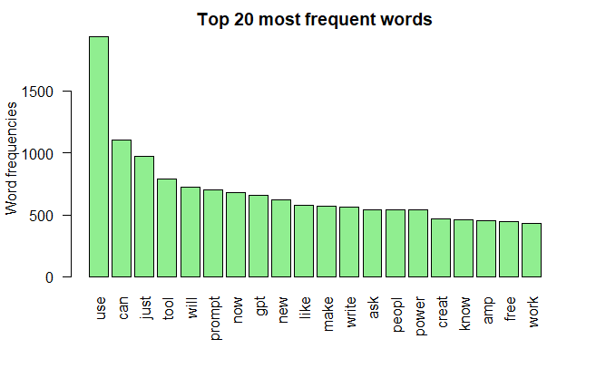

```r
return_top20_words(corpus_clean_tweets)
```

[figure not shown]

```r
return_text_cloud(tweets1)
```

We can see from the above histogram and text-cloud, that the most used words in the recent tweets are quite positive, for example words like ‘great’, ‘use’, ‘potential’, ‘free’, ‘best’, ‘powerful’, ‘top’, etc.

```r
sentiment_tweets<-perform_sentiment_analysis(tweets1)
```

```
   Min. 1st Qu.  Median    Mean 3rd Qu.    Max.
-3.8500  0.0000  0.5000  0.5221  1.0000  7.8000
```

```r
sentiment_tweets$final_sentiment <- ifelse(sentiment_tweets$syuzhet_vector1 > 0.1, "Positive",
                                   ifelse(sentiment_tweets$syuzhet_vector1 < -0.1, "Negative",
                                          "Neutral"))
sentiment_summary <- table(sentiment_tweets$final_sentiment)
sentiment_summary
```

```
Negative  Neutral Positive
    1872     2255     5873
```

```r
summary.data.frame(sentiment_tweets)
```

```
 syuzhet_vector1   final_sentiment
 Min.   :-3.8500   Length:10000
 1st Qu.: 0.0000   Class :character
 Median : 0.5000   Mode  :character
 Mean   : 0.5221
 3rd Qu.: 1.0000
 Max.   : 7.8000
```

The results of sentiment analysis show that the overall sentiment towards chatGPT in tweets is positive as the mean and median sentiments are both positive. Also, the number of positive tweets are much more prevalent than the number of negative tweets.

```r
perform_LDA(tweets1)
```

| Topic 1 | Topic 2 | Topic 3 | Topic 4 | Topic 5 | Topic 6 | Topic 7 | Topic 8 | Topic 9 | Topic 10 | Topic 11 | Topic 12 | Topic 13 | Topic 14 | Topic 15 |
| --- | --- | --- | --- | --- | --- | --- | --- | --- | --- | --- | --- | --- | --- | --- |
| just | premium | ai | ai | prompt | use | use | google | know | prompt | use | 号 | ai | code | ai |
| ask | account | will | model | hour | write | ai | now | use | token | can | 账 | tool | can | make |
| now | canva | job | datum | amp | research | people | just | ask | free | make | good | new | use | will |
| lot | ph | say | language | work | like | 5 | bard | question | course | one | year | just | get | use |
| guy | pro | take | new | write | make | many | ai | good | learn | think | will | release | create | just |
| get | netflix | replace | amp | good | fake | stop | can | answer | airdrop | like | gpt4 | 10 | gpt4 | way |
| may | grammarly | new | openai | save | create | just | free | assistant | excite | even | world | 8 | search | good |
| think | spotify | generative | now | 50 | paper | make | big | technology | engineer | need | time | 3 | ai | extension |
| launch | quillbot | chatbot | power | 10 | generate | time | thing | life | check | look | take | 7 | website | people |
| potential | viu | create | can | add | even | extension | take | change | follow | way | can | week | build | know |

On performing LDA we can clearly identify similarity between topics. For example, the topic 2 concerns about apps such as grammarly, quillbot, netflix, spotify which requires paid subscriptions to access them. Topic 3 concerns about how the chatgpt would affect the job market, as suggested by the words ‘job’, ‘replace’. Topic 6 shows concerns regarding fake research papers generated using AI. Thus, LDA does provide us with prevailing public opinions and sentiments related to chatgpt.

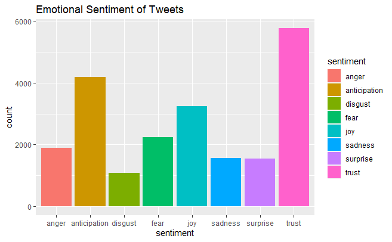

```r
plot_sentiment(tweets1)
```

The sentiment plot also provide a clear evidence of positive sentiment. Also, we can note that the anticipation count is high , which implies that people are looking forward to the further updates on chatgpt with eagerness and enthusiasm.

**Analysis for Subquestion 1:**

Now, we will check if the public sentiment, topics of discussions, are same over other social media sources such as reddit comments and the news articles:

```r
sentiment_reddit<-perform_sentiment_analysis(reddit)
```

```
   Min. 1st Qu.  Median    Mean 3rd Qu.    Max.
-7.7500  0.0000  0.4000  0.7149  1.2500 26.2500
```

```r
summary.data.frame(sentiment_reddit)
```

```
 syuzhet_vector1
 Min.   :-7.7500
 1st Qu.: 0.0000
 Median : 0.4000
 Mean   : 0.7149
 3rd Qu.: 1.2500
 Max.   :26.2500
```

We can note that the mean value of sentiment analysis is higher for the reddit comments, whereas the median is lower than the tweets. This suggests that the number of people who write positive about chatGPT are more on twitter, but the intensity of positivity is higher for the reddit comments.

```r
sentiment_reddit$final_sentiment <- ifelse(sentiment_reddit$syuzhet_vector1 > 0.1, "Positive",
                                   ifelse(sentiment_reddit$syuzhet_vector1 < -0.1, "Negative",
                                          "Neutral"))
sentiment_summary <- table(sentiment_reddit$final_sentiment)
sentiment_summary
```

```
Negative  Neutral Positive
    2214     2149     5637
```

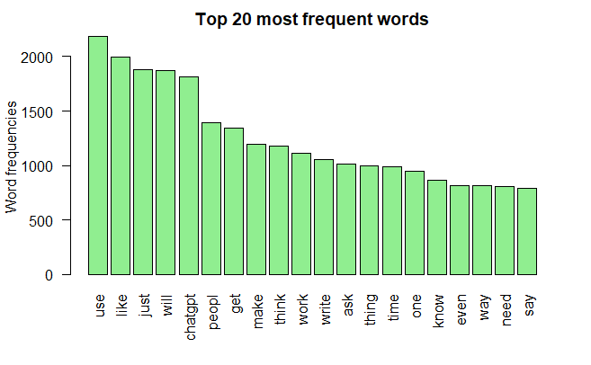

```r
return_top20_words(corpus_clean_reddit)
```

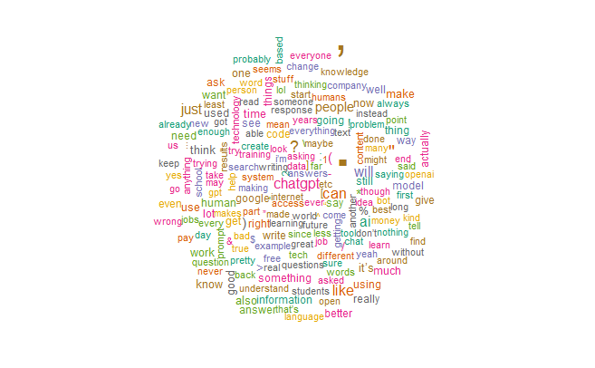

```r
return_text_cloud(reddit)
```

We can note that words in the textcloud are a little different than the ones for the tweets. Reddit comments seems to be using a more casual language as the words ‘lol’, ‘:(’, etc. We further look at the results of LDA to get a clearer distinction among topics.

```r
perform_LDA(reddit)
```

| Topic 1 | Topic 2 | Topic 3 | Topic 4 | Topic 5 | Topic 6 | Topic 7 | Topic 8 | Topic 9 | Topic 10 | Topic 11 | Topic 12 | Topic 13 | Topic 14 | Topic 15 |
| --- | --- | --- | --- | --- | --- | --- | --- | --- | --- | --- | --- | --- | --- | --- |
| ai | it’s | model | bot | pay | like | student | write | think | prompt | > | people | answer | year | google |
| will | don’t | train | use | company | just | write | code | can | can | write | get | ask | now | search |
| people | i’m | can | comment | will | make | school | use | human | get | word | like | question | go | good |
| job | just | use | can | money | say | learn | can | thing | will | letter | just | give | just | use |
| human | say | language | good | make | know | essay | work | good | like | good | good | get | time | result |
| can | that’s | ai | delete | get | get | use | good | mean | want | ask | make | know | day | like |
| need | thing | datum | chat | use | try | class | just | just | try | will | go | can | like | information |
| think | like | information | thank | just | something | paper | ask | say | give | one | think | wrong | new | answer |
| work | doesn’t | text | post | free | feel | teacher | thing | make | tell | just | lot | try | ago | internet |
| art | know | response | now | openai | sound | think | like | even | character | give | will | just | one | just |

Here, topic 7 probably are concerns about the school students using chatgpt to write essays, the topic 4 are concerns about the bot being able to chat, post, comment, delete now, topic 14 maybe wants to imply how the time is changing, topic 8 might be praising the ability of chatgpt to be able to provide with codes. Few topics seem common among both the twitter, and reddit whereas few differ.

We repeat the same process for news articles:

```r
sentiment_news<-perform_sentiment_analysis(news_articles)
```

```
   Min. 1st Qu.  Median    Mean 3rd Qu.    Max.
-5.2000  0.0000  0.6500  0.6646  1.6000  4.4500
```

```r
summary.data.frame(sentiment_news)
```

```
 syuzhet_vector1
 Min.   :-5.2000
 1st Qu.: 0.0000
 Median : 0.6500
 Mean   : 0.6646
 3rd Qu.: 1.6000
 Max.   : 4.4500
```

```r
sentiment_news$final_sentiment <- ifelse(sentiment_news$syuzhet_vector1 > 0.1, "Positive",
                                   ifelse(sentiment_news$syuzhet_vector1 < -0.1, "Negative",
                                          "Neutral"))
sentiment_summary <- table(sentiment_news$final_sentiment)
sentiment_summary
```

```
Negative  Neutral Positive
     113       52      340
```

We do not have 10000 news articles, due to shortage of time we could not scrape as many as tweets. But we can clearly see that both the mean and median values of sentiments are higher for news articles than the tweets. The number of positive news articles are almost thrice the number of negative articles.

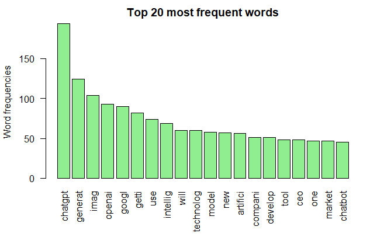

```r
return_top20_words(corpus_clean_news)
```

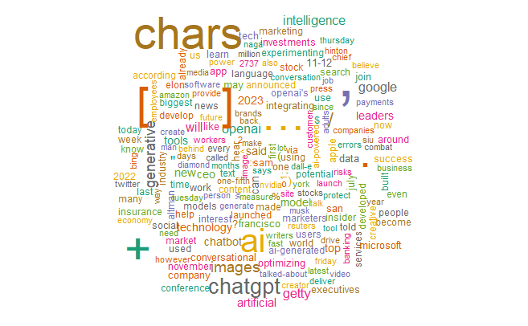

```r
return_text_cloud(news_articles)
```

```r
perform_LDA(news_articles)
```

| Topic 1 | Topic 2 | Topic 3 | Topic 4 | Topic 5 | Topic 6 | Topic 7 | Topic 8 | Topic 9 | Topic 10 | Topic 11 | Topic 12 | Topic 13 | Topic 14 | Topic 15 |
| --- | --- | --- | --- | --- | --- | --- | --- | --- | --- | --- | --- | --- | --- | --- |
| technology | intelligence | creator | char | char | tool | ai | > | char | char | < | char | google | ai | ai |
| char | artificial | char | generative | like | social | char | < | openai | ai | > | good | char | char | hear |
| model | char | power | ai | may | new | can | li | sam | new | li | week | app | model | executive |
| conversational | technology | ai | help | get | ai | time | ul | altman | use | ul | world | search | one | leader |
| openai | company | already | will | news | char | potential | char | ai | job | image | us | microsoft | language | top |
| 2023 | use | economy | can | business | market | tool | use | elon | work | getty | make | ai | become | integrate |
| ai | amazon | develop | create | ai | medium | generative | generative | datum | google | char | diamond | o | generative | san |
| build | launch | expand | ai-powered | back | insider | generate | abuse | ceo | report | ai | naga | launch | openai | francisco |
| talked-about | writer | experiment | chatbot | way | every | 2023 | datum | musk | market | say | last | announce | late | learn |
| interest | system | creative | image | will | already | video | build | want | will | ceo | siu | make | work | investment |

News articles generally adhere to formal language and a professional tone, so can be seen by the word cloud and the LDA. Since the news articles are meant to cover wider audience, the topics here are more generalized to the society. For example, the tweets and reddit comments seemes to be personal views about the chatGPT, but the news articles not only covers the common topics such as job markets (Topic 10), but also concerns about how chatgpt and ai could expand and develop the economy (Topic 3), the blogs as the Topic 6 includes words such as Medium, Insider, the Topic 9 consists of CEOs such as Elon Musk, Sam Altman.

Thus we can conclude that overall the positive sentiment seems to prevail among all the media sources, but the topics, concerns, and views change with the source of media. The twitter and reddit still share some commonalities, but the news articles seem to have completely different concerns about chatgpt, which is explainable because twitter and reddit are often more informal and conversational in nature, allowing for personal opinions, slang, and abbreviations or a casual language in comparison to news articles are informative and formal.

**Analysis for Subquestion 2:**

1. Now we look at the tweets when the chatgpt was just launched, and how the sentiment evolved over time.

```r
sentiment_tweets_dec<-perform_sentiment_analysis(tweets_dec)
```

```
   Min. 1st Qu.  Median    Mean 3rd Qu.    Max.
-5.2500  0.0000  0.4500  0.5454  1.0500  7.6000
```

```r
summary.data.frame(sentiment_tweets_dec)
```

```
 syuzhet_vector1
 Min.   :-5.2500
 1st Qu.: 0.0000
 Median : 0.4500
 Mean   : 0.5454
 3rd Qu.: 1.0500
 Max.   : 7.6000
```

```r
sentiment_tweets_dec$final_sentiment <- ifelse(sentiment_tweets_dec$syuzhet_vector1 > 0.1, "Positive",
                                   ifelse(sentiment_tweets_dec$syuzhet_vector1 < -0.1, "Negative",
                                          "Neutral"))
sentiment_summary <- table(sentiment_tweets_dec$final_sentiment)
sentiment_summary
```

```
Negative  Neutral Positive
    1873     2387     5740
```

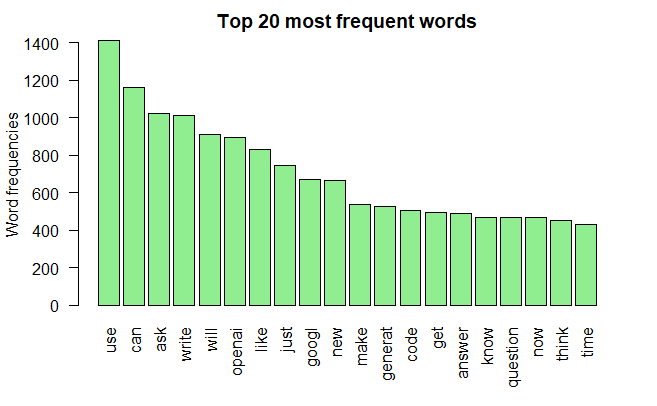

```r
return_top20_words(corpus_clean_tweets_dec)
```

The top 20 words suggests that people were talking about how the chatgpt could be used, its ability to generate codes, answer the questions, write stuff, etc.

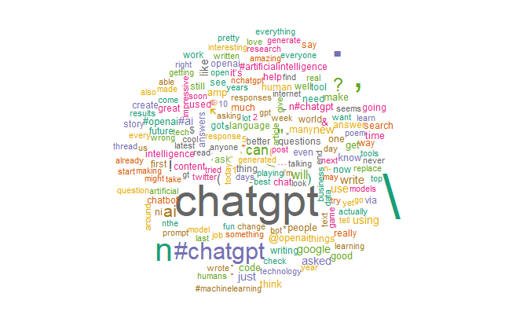

```r
return_text_cloud(tweets_dec)
```

```r
perform_LDA(tweets_dec)
```

| Topic 1 | Topic 2 | Topic 3 | Topic 4 | Topic 5 | Topic 6 | Topic 7 | Topic 8 | Topic 9 | Topic 10 | Topic 11 | Topic 12 | Topic 13 | Topic 14 | Topic 15 |
| --- | --- | --- | --- | --- | --- | --- | --- | --- | --- | --- | --- | --- | --- | --- |
| ai | try | model | will | day | will | ai | write | use | google | write | like | now | answer | code |
| chatbot | just | language | ai | year | ai | openai | ask | ai | search | ask | know | openai | question | use |
| new | good | use | like | time | human | intelligence | good | can | will | story | feel | good | ask | can |
| via | blow | train | change | use | job | artificial | essay | write | new | see | good | make | give | write |
| amp | get | can | world | 5 | think | nchatgpt | can | content | use | ai | think | think | get | work |
| bot | fun | datum | future | take | can | artificialintelligence | ai | create | replace | tweet | just | can | just | ask |
| chat | mind | learn | know | week | replace | chatbot | poem | generate | good | prompt | make | get | know | python |
| learn | use | openai | year | next | people | new | one | tool | chat | use | people | see | right | learn |
| talk | play | human | go | nchatgpt | good | technology | get | text | code | twitter | thing | go | wrong | program |
| artificialintelligence | pretty | generate | thing | user | content | late | make | make | may | thread | need | work | can | help |

```r
sentiment_jan_mar<-perform_sentiment_analysis(tweets_jan_mar)
```

```
   Min. 1st Qu.  Median    Mean 3rd Qu.    Max.
-5.4000  0.0000  0.5000  0.6656  1.2500  7.2500
```

```r
summary.data.frame(sentiment_jan_mar)
```

```
 syuzhet_vector1
 Min.   :-5.4000
 1st Qu.: 0.0000
 Median : 0.5000
 Mean   : 0.6656
 3rd Qu.: 1.2500
 Max.   : 7.2500
```

Now, since we have the tweets from November to May, we take the mean sentiment of each month and plot it using a line chart in order to visualize the change of sentiment over time.

```r
tweets1['sentiment']<-sentiment_tweets['syuzhet_vector1']
tweets_dec['sentiment']<-sentiment_tweets_dec['syuzhet_vector1']
tweets_jan_mar['sentiment']<-sentiment_jan_mar['syuzhet_vector1']
```

```r
library(stringr)
tweets1['date']<-sapply(str_split(tweets1$tweet_extracted, " "), "[[", 1)
tweets1['month']<-sapply(str_split(tweets1$date, "-"), "[[", 2)
sent_recent <- tweets1 %>%
  group_by(month) %>%
  summarize(mean_value = mean(sentiment))
sent_recent
```

| month | mean_value |
| --- | --- |
| 04 | 0.5402137 |
| 05 | 0.4891163 |

```r
tweets_jan_mar['date']<-sapply(str_split(tweets_jan_mar$date, " "), "[[", 1)
tweets_jan_mar['month']<-sapply(str_split(tweets_jan_mar$date, "-"), "[[", 2)
sent_jan_mar <- tweets_jan_mar %>%
  group_by(month) %>%
  summarize(mean_value = mean(sentiment))
sent_jan_mar
```

[output not shown]

```r
tweets_jan_mar['date']<-sapply(str_split(tweets_jan_mar$date, " "), "[[", 1)
tweets_jan_mar['month']<-sapply(str_split(tweets_jan_mar$date, "-"), "[[", 2)
sent_jan_mar <- tweets_jan_mar %>%
  group_by(month) %>%
  summarize(mean_value = mean(sentiment))
sent_jan_mar
```

| month | mean_value |
| --- | --- |
| 01 | 0.6540487 |
| 02 | 0.6312098 |
| 03 | 0.7051888 |

```r
tweets_dec['date']<-sapply(str_split(tweets_dec$created_at, " "), "[[", 1)
tweets_dec['month']<-sapply(str_split(tweets_dec$date, "-"), "[[", 2)
sent_dec <- tweets_dec %>%
  group_by(month) %>%
  summarize(mean_value = mean(sentiment))
sent_dec
```

| month | mean_value |
| --- | --- |
| 11 | 0.7230769 |
| 12 | 0.5452038 |

```r
# Combine the tibbles using bind_rows()
combined <- bind_rows(sent_dec, sent_jan_mar, sent_recent)
combined['Mon']<-c("Nov", "Dec", "Jan", "Feb", "Mar", "Apr", "May")
# View the combined tibble
print(combined)
```

| month | mean_value | Mon |
| --- | --- | --- |
| 11 | 0.7230769 | Nov |
| 12 | 0.5452038 | Dec |
| 01 | 0.6540487 | Jan |
| 02 | 0.6312098 | Feb |
| 03 | 0.7051888 | Mar |
| 04 | 0.5402137 | Apr |
| 05 | 0.4891163 | May |

We can clearly see that during the launch, the people were more supportive, there may have been high expectations and excitement about the ChatGPT’s capabilities. However, as users interacted more and more with the system and discovered its limitations or encountered instances of inaccurate or inappropriate responses, it might have led to a decrease in positivity. Moreover, the increased awareness of the issues such as biases, misinformation generation, and privacy would have induced some fear among the people. Also, people could be concerned about losing their jobs as the AI models like chatGPT could replace their work. The learnings of students could be affected as well, as everything being available for free might lead to laziness and dependence on such AI models for homeworks, and assignments. There could be several other reasons for reduced positivity among people regarding chatGPT.